# Uygulamalı Mekansal İstatistiksel Yöntemler Proje

Yakup Tarık AÇAN

> Verimizi import ediyoruz.

```r
mean_meat <- readShapePoly("mean_meat_pro_and_live_EU/mean_meat_pro_and_live_EU.shp",IDvar="NAME")
```

> Koordinatlarımızı ayrı bir değişkene atıyoruz.

```r
coords <- coordinates(mean_meat)
```

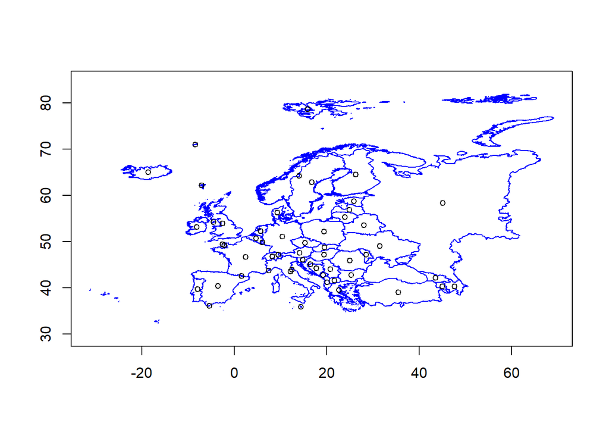

```r
plot(mean_meat, border="blue", axes=TRUE)
points(coords, cex=0.8)
```

> “k-Nearest neighbours” komşulukta baz alınacak uzaklıkları hesaplıyoruz. Ve Mekansal Birim Kodu “1” olan değeri inceliyoruz.

```r
knn1IT <- knn2nb(knearneigh(coords,k=1,longlat=T))
knn1IT[1]
```

```
## [[1]]
## [1] 33
```

> KNN idlerini kontrol amaçlı harita üzerinde inceliyoruz.

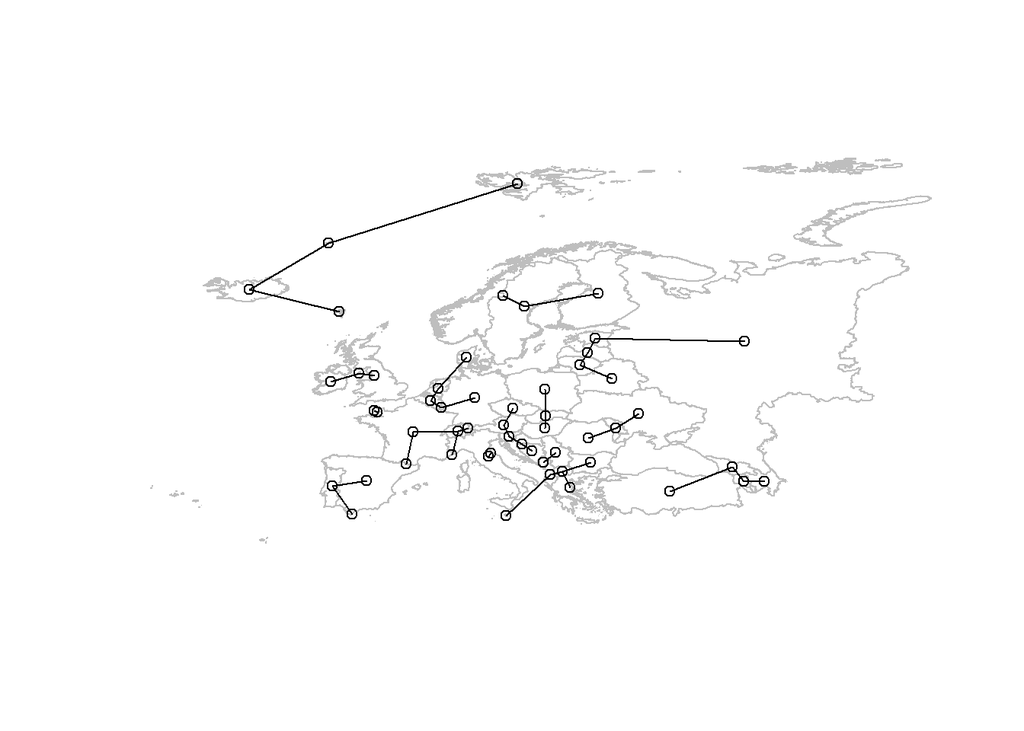

```r
plot(mean_meat, border="grey")
plot(knn1IT, coords, add=TRUE)
```

> KNN’ lerin “k” katsayısı üzerinde değişiklik yparak aralarındaki farklara bakalım.

```r
knn4IT <- knn2nb(knearneigh(coords,k=4,longlat=T))
```

> “k=4” değerlerimizi harita üzerinde görselleştirelim.

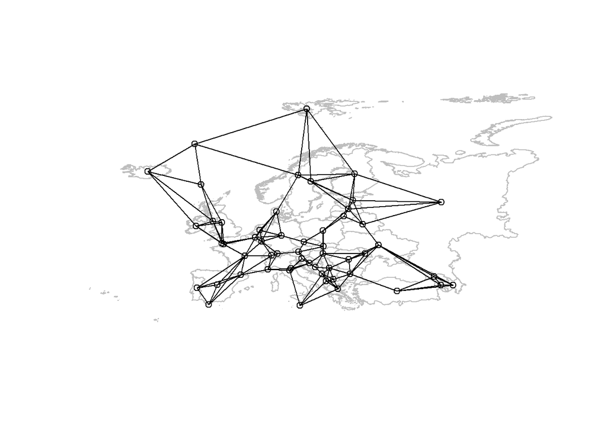

```r
plot(mean_meat, border="grey")
plot(knn4IT, coords, add=TRUE)
```

> Bu şekilde yaptığımızda daha fazla ülkenin komşu olarak işaretlendiğini görebiliyoruz.

> “Critical cut-off neighbourhood” kullanarak komşuluk birimi hesaplama

> Komşusuz birimin kalmaması için en kısa mesafenin hesaplanmasını yapalım.

```r
knn1IT <- knn2nb(knearneigh(coords,k=1,longlat=T))
all.linkedT <- max(unlist(nbdists(knn1IT, coords, longlat=T)))
all.linkedT
```

```
## [1] 1115.863
```

```r
dnb1970.639 <- dnearneigh(coords, 0, 1970.639, longlat=TRUE); dnb1970.639
```

```
## Neighbour list object:
## Number of regions: 54
## Number of nonzero links: 1748
## Percentage nonzero weights: 59.94513
## Average number of links: 32.37037
```

```r
dnb2970.639 <- dnearneigh(coords, 0, 2970.639, longlat=TRUE); dnb2970.639
```

```
## Neighbour list object:
## Number of regions: 54
## Number of nonzero links: 2492
## Percentage nonzero weights: 85.45953
## Average number of links: 46.14815
```

```r
dnb3970.639 <- dnearneigh(coords, 0, 3970.639, longlat=TRUE); dnb3970.639
```

```
## Neighbour list object:
## Number of regions: 54
## Number of nonzero links: 2780
## Percentage nonzero weights: 95.33608
## Average number of links: 51.48148
```

```r
dnb4970.639 <- dnearneigh(coords, 0, 4970.639, longlat=TRUE); dnb4970.639
```

```
## Neighbour list object:
## Number of regions: 54
## Number of nonzero links: 2862
## Percentage nonzero weights: 98.14815
## Average number of links: 53
```

```r
dnb5970.639 <- dnearneigh(coords, 0, 5970.639, longlat=TRUE); dnb5970.639
```

```
## Neighbour list object:
## Number of regions: 54
## Number of nonzero links: 2862
## Percentage nonzero weights: 98.14815
## Average number of links: 53
```

```r
dnb6970.639 <- dnearneigh(coords, 0, 6970.639, longlat=TRUE); dnb6970.639
```

```
## Neighbour list object:
## Number of regions: 54
## Number of nonzero links: 2862
## Percentage nonzero weights: 98.14815
## Average number of links: 53
```

> “cut-off” mesafesi arttıkça ülkeler arası komşuluk sayılarıda artmasını bekliyoruz harita üzerinde görselleştirip inceleyelim.

[figure not shown]

```r
plot(mean_meat, border="grey",xlab="",ylab="",xlim=NULL)
title(main="d nearest neighbours, d = 1970.639")
plot(dnb2970.639, coords, add=TRUE, col="magenta")
```

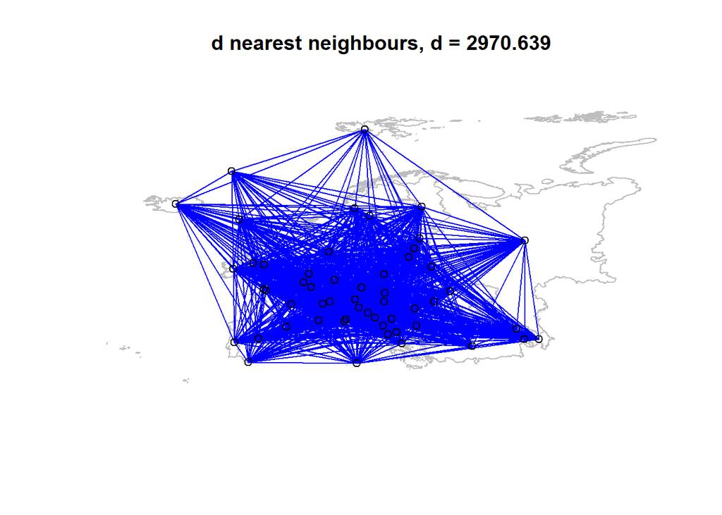

```r
plot(mean_meat, border="grey",xlab="",ylab="",xlim=NULL)
title(main="d nearest neighbours, d = 2970.639")
plot(dnb2970.639, coords, add=TRUE, col="blue")
```

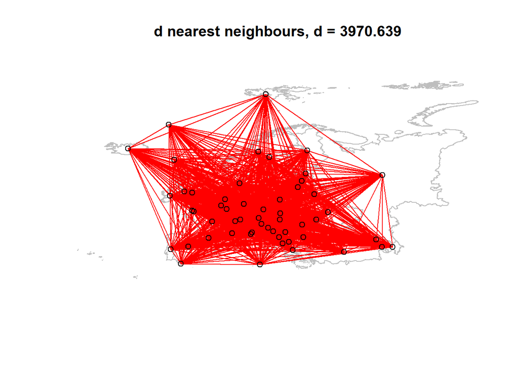

```r
plot(mean_meat, border="grey",xlab="",ylab="",xlim=NULL)
title(main="d nearest neighbours, d = 3970.639")
plot(dnb3970.639, coords, add=TRUE, col="red")
```

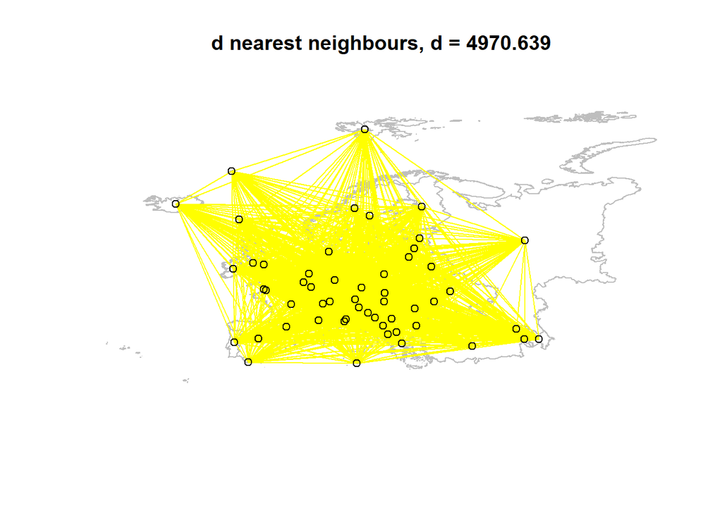

```r
plot(mean_meat, border="grey",xlab="",ylab="",xlim=NULL)
title(main="d nearest neighbours, d = 4970.639")
plot(dnb4970.639, coords, add=TRUE, col="yellow" )
```

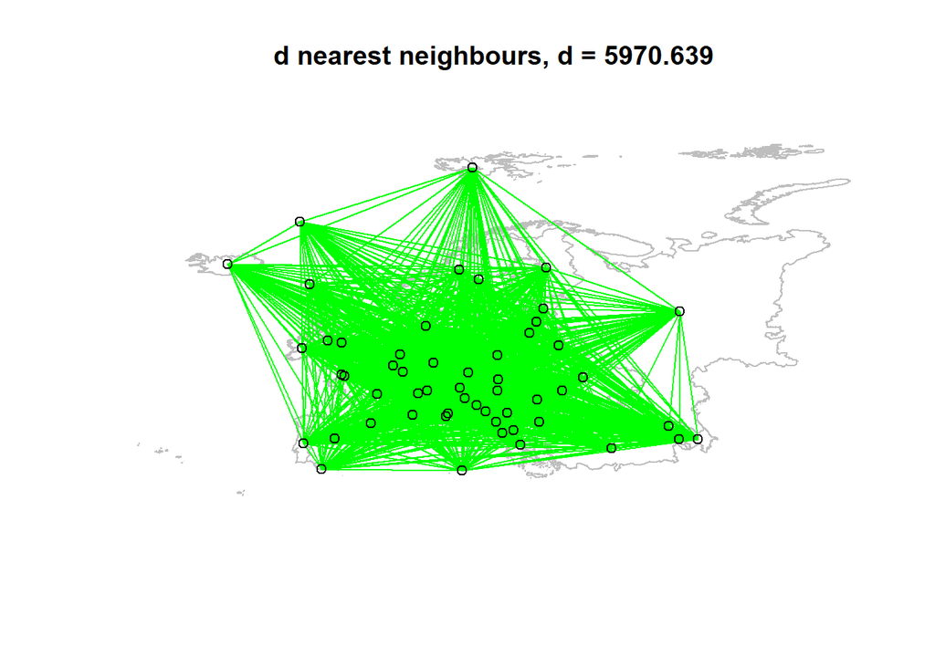

```r
plot(mean_meat, border="grey",xlab="",ylab="",xlim=NULL)
title(main="d nearest neighbours, d = 5970.639")
plot(dnb5970.639, coords, add=TRUE, col="green")
```

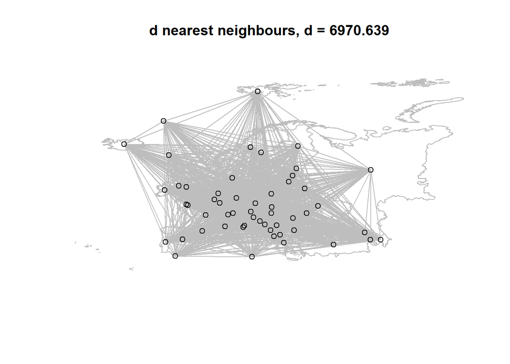

```r
plot(mean_meat, border="grey",xlab="",ylab="",xlim=NULL)
title(main="d nearest neighbours, d = 6970.639")
plot(dnb6970.639, coords, add=TRUE, col="grey")
```

> “Süreklilik Bazlı Komşuluk Birimi (Contiguity-based neighbourhood)” kullanarak komşuluk birimi hesaplama

> Birbirlerine sınırı olan ülkeleri komşu olarak alarak komşuluk birimlerimizi inceleyelim.

```r
contnb_q <- poly2nb(mean_meat, queen=T)
contnb_q
```

```
## Neighbour list object:
## Number of regions: 54
## Number of nonzero links: 186
## Percentage nonzero weights: 6.378601
## Average number of links: 3.444444
## 8 regions with no links:
## Faeroe Islands (Denmark) Guernsey (UK) Iceland Isle of Man (UK) Jan
## Mayen (Norway) Jersey (UK) Malta Svalbard (Norway)
```

> Harita Üzerinde görselleştirmesini inceleyelim.

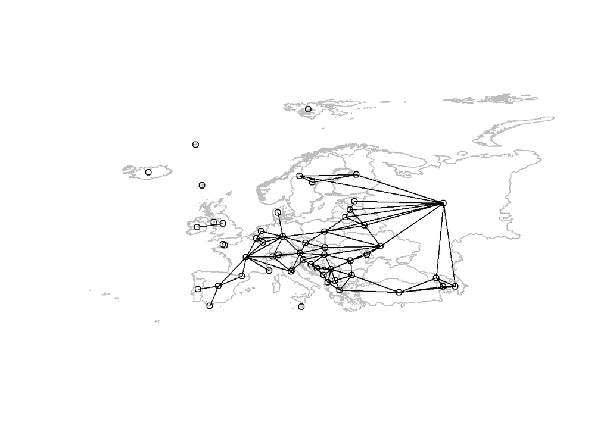

```r
plot(mean_meat, border="grey")
plot(contnb_q, coords, add=TRUE)
```

> Mekansal Ağırlık Matrisi oluşturalım.

> Satır-Standardizasyonu yapılmış mekansal ağırlık matrislerini oluşturalım.

```r
dnb1970.639.listw<-nb2listw(dnb1970.639,style="W",zero.policy=T)
dnb2970.639.listw<-nb2listw(dnb2970.639,style="W",zero.policy=T)
dnb3970.639.listw<-nb2listw(dnb3970.639,style="W",zero.policy=F)
dnb4970.639.listw<-nb2listw(dnb4970.639,style="W",zero.policy=F)
dnb5970.639.listw<-nb2listw(dnb5970.639,style="W",zero.policy=F)
dnb6970.639.listw<-nb2listw(dnb6970.639,style="W",zero.policy=F)
```

> Mekansal Otokorelasyon testi “The Moran’s I“

> 2000-2018 yılları arası ortalama Sığır, Domuz ve Kümes hayvanı eti Üretimi ve canlı hayvan stokları arasındaki otokorelasyona bakalım.

> Cattle

```r
model_cattle <- lm(mean_meat_~mean_mea_1, data = mean_meat)
studres <- rstudent(model_cattle)
#acf(model_cattle$residuals, type = "correlation")
```

```r
brks_cattle <- quantile(studres)
colours <- grey((length(brks_cattle):2)/length(brks_cattle))
```

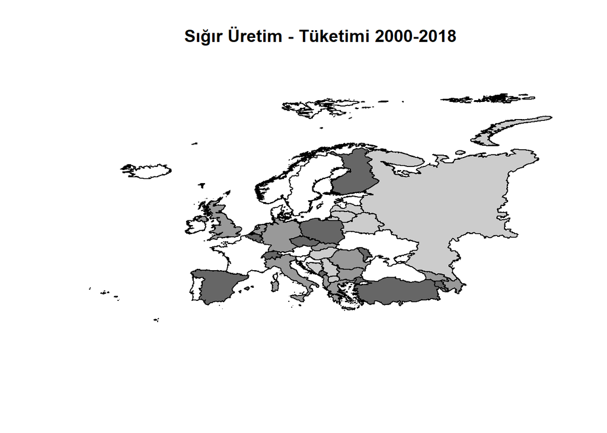

```r
plot(mean_meat, col=colours[findInterval(studres, brks_cattle,
all.inside=TRUE)])
title(main="Sığır Üretim - Tüketimi 2000-2018")
```

```r
lm.morantest(model_cattle,dnb1970.639.listw,resfun=rstudent)
```

```
##
##  Global Moran I for regression residuals
##
## data:
## model: lm(formula = mean_meat_ ~ mean_mea_1, data = mean_meat)
## weights: dnb1970.639.listw
##
## Moran I statistic standard deviate = 1.5425, p-value = 0.06148
## alternative hypothesis: greater
## sample estimates:
## Observed Moran I      Expectation         Variance
##     0.0073844052    -0.0272502652     0.0005041833
```

```r
lm.morantest(model_cattle,dnb2970.639.listw,resfun=rstudent)
```

```
##
##  Global Moran I for regression residuals
##
## data:
## model: lm(formula = mean_meat_ ~ mean_mea_1, data = mean_meat)
## weights: dnb2970.639.listw
##
## Moran I statistic standard deviate = -0.060894, p-value = 0.5243
## alternative hypothesis: greater
## sample estimates:
## Observed Moran I      Expectation         Variance
##    -2.746193e-02    -2.707344e-02     4.070044e-05
```

```r
lm.morantest(model_cattle,dnb3970.639.listw,resfun=rstudent)
```

```
##
##  Global Moran I for regression residuals
##
## data:
## model: lm(formula = mean_meat_ ~ mean_mea_1, data = mean_meat)
## weights: dnb3970.639.listw
##
## Moran I statistic standard deviate = 0.20894, p-value = 0.4172
## alternative hypothesis: greater
## sample estimates:
## Observed Moran I      Expectation         Variance
##    -2.757514e-02    -2.784317e-02     1.645701e-06
```

```r
lm.morantest(model_cattle,dnb4970.639.listw,resfun=rstudent)
```

```
##
##  Global Moran I for regression residuals
##
## data:
## model: lm(formula = mean_meat_ ~ mean_mea_1, data = mean_meat)
## weights: dnb4970.639.listw
##
## Moran I statistic standard deviate = NaN, p-value = NA
## alternative hypothesis: greater
## sample estimates:
## Observed Moran I      Expectation         Variance
##    -2.737686e-02    -2.777778e-02    -1.168092e-18
```

```r
lm.morantest(model_cattle,dnb5970.639.listw,resfun=rstudent)
```

```
##
##  Global Moran I for regression residuals
##
## data:
## model: lm(formula = mean_meat_ ~ mean_mea_1, data = mean_meat)
## weights: dnb5970.639.listw
##
## Moran I statistic standard deviate = NaN, p-value = NA
## alternative hypothesis: greater
## sample estimates:
## Observed Moran I      Expectation         Variance
##    -2.737686e-02    -2.777778e-02    -1.168092e-18
```

```r
lm.morantest(model_cattle,dnb6970.639.listw,resfun=rstudent)
```

```
##
##  Global Moran I for regression residuals
##
## data:
## model: lm(formula = mean_meat_ ~ mean_mea_1, data = mean_meat)
## weights: dnb6970.639.listw
##
## Moran I statistic standard deviate = NaN, p-value = NA
## alternative hypothesis: greater
## sample estimates:
## Observed Moran I      Expectation         Variance
##    -2.737686e-02    -2.777778e-02    -1.168092e-18
```

> Pig

```r
model_pig <- lm(mean_mea_4~mean_mea_5, data = mean_meat)
studres <- rstudent(model_cattle)
```

```r
brks_pig <- quantile(studres)
colours <- grey((length(brks_pig):2)/length(brks_pig))
```

[figure not shown]

```r
plot(mean_meat, col=colours[findInterval(studres, brks_pig,
all.inside=TRUE)])
title(main="Domuz Üretim - Tüketimi 2000-2018")
```

```r
lm.morantest(model_pig,dnb1970.639.listw,resfun=rstudent)
```

```
##
##  Global Moran I for regression residuals
##
## data:
## model: lm(formula = mean_mea_4 ~ mean_mea_5, data = mean_meat)
## weights: dnb1970.639.listw
##
## Moran I statistic standard deviate = -0.15502, p-value = 0.5616
## alternative hypothesis: greater
## sample estimates:
## Observed Moran I      Expectation         Variance
##    -0.0313359238    -0.0278749530     0.0004984422
```

```r
lm.morantest(model_pig,dnb2970.639.listw,resfun=rstudent)
```

```
##
##  Global Moran I for regression residuals
##
## data:
## model: lm(formula = mean_mea_4 ~ mean_mea_5, data = mean_meat)
## weights: dnb2970.639.listw
##
## Moran I statistic standard deviate = 0.13344, p-value = 0.4469
## alternative hypothesis: greater
## sample estimates:
## Observed Moran I      Expectation         Variance
##    -2.670882e-02    -2.756932e-02     4.158233e-05
```

```r
lm.morantest(model_pig,dnb3970.639.listw,resfun=rstudent)
```

```
##
##  Global Moran I for regression residuals
##
## data:
## model: lm(formula = mean_mea_4 ~ mean_mea_5, data = mean_meat)
## weights: dnb3970.639.listw
##
## Moran I statistic standard deviate = 2.3421, p-value = 0.009588
## alternative hypothesis: greater
## sample estimates:
## Observed Moran I      Expectation         Variance
##    -2.430017e-02    -2.779729e-02     2.229525e-06
```

```r
lm.morantest(model_pig,dnb4970.639.listw,resfun=rstudent)
```

```
##
##  Global Moran I for regression residuals
##
## data:
## model: lm(formula = mean_mea_4 ~ mean_mea_5, data = mean_meat)
## weights: dnb4970.639.listw
##
## Moran I statistic standard deviate = 5463904, p-value < 2.2e-16
## alternative hypothesis: greater
## sample estimates:
## Observed Moran I      Expectation         Variance
##    -2.497808e-02    -2.777778e-02     2.625527e-19
```

```r
lm.morantest(model_pig,dnb5970.639.listw,resfun=rstudent)
```

```
##
##  Global Moran I for regression residuals
##
## data:
## model: lm(formula = mean_mea_4 ~ mean_mea_5, data = mean_meat)
## weights: dnb5970.639.listw
##
## Moran I statistic standard deviate = 5463904, p-value < 2.2e-16
## alternative hypothesis: greater
## sample estimates:
## Observed Moran I      Expectation         Variance
##    -2.497808e-02    -2.777778e-02     2.625527e-19
```

```r
lm.morantest(model_pig,dnb6970.639.listw,resfun=rstudent)
```

```
##
##  Global Moran I for regression residuals
##
## data:
## model: lm(formula = mean_mea_4 ~ mean_mea_5, data = mean_meat)
## weights: dnb6970.639.listw
##
## Moran I statistic standard deviate = 5463904, p-value < 2.2e-16
## alternative hypothesis: greater
## sample estimates:
## Observed Moran I      Expectation         Variance
##    -2.497808e-02    -2.777778e-02     2.625527e-19
```

> Poultry

```r
model_poultry <- lm(mean_mea_2~mean_mea_3, data = mean_meat)
studres <- rstudent(model_cattle)
```

```r
brks_poultry <- quantile(studres)
colours <- grey((length(brks_poultry):2)/length(brks_poultry))
```

[figure not shown]

```r
plot(mean_meat, col=colours[findInterval(studres, brks_poultry,
all.inside=TRUE)])
title(main="Kümes Hayvanlarının Üretim - Tüketimi 2000-2018")
```

```r
lm.morantest(model_poultry,dnb1970.639.listw,resfun=rstudent)
```

```
##
##  Global Moran I for regression residuals
##
## data:
## model: lm(formula = mean_mea_2 ~ mean_mea_3, data = mean_meat)
## weights: dnb1970.639.listw
##
## Moran I statistic standard deviate = 6.431, p-value = 6.337e-11
## alternative hypothesis: greater
## sample estimates:
## Observed Moran I      Expectation         Variance
##     0.1198386197    -0.0271565311     0.0005224508
```

```r
lm.morantest(model_poultry,dnb2970.639.listw,resfun=rstudent)
```

```
##
##  Global Moran I for regression residuals
##
## data:
## model: lm(formula = mean_mea_2 ~ mean_mea_3, data = mean_meat)
## weights: dnb2970.639.listw
##
## Moran I statistic standard deviate = 5.9342, p-value = 1.477e-09
## alternative hypothesis: greater
## sample estimates:
## Observed Moran I      Expectation         Variance
##     0.0103591492    -0.0271971626     0.0000400538
```

```r
lm.morantest(model_poultry,dnb3970.639.listw,resfun=rstudent)
```

```
##
##  Global Moran I for regression residuals
##
## data:
## model: lm(formula = mean_mea_2 ~ mean_mea_3, data = mean_meat)
## weights: dnb3970.639.listw
##
## Moran I statistic standard deviate = 2.8332, p-value = 0.002304
## alternative hypothesis: greater
## sample estimates:
## Observed Moran I      Expectation         Variance
##    -2.414274e-02    -2.780944e-02     1.674976e-06
```

```r
lm.morantest(model_poultry,dnb4970.639.listw,resfun=rstudent)
```

```
##
##  Global Moran I for regression residuals
##
## data:
## model: lm(formula = mean_mea_2 ~ mean_mea_3, data = mean_meat)
## weights: dnb4970.639.listw
##
## Moran I statistic standard deviate = 438716, p-value < 2.2e-16
## alternative hypothesis: greater
## sample estimates:
## Observed Moran I      Expectation         Variance
##    -2.721785e-02    -2.777778e-02     1.628899e-18
```

```r
lm.morantest(model_poultry,dnb5970.639.listw,resfun=rstudent)
```

```
##
##  Global Moran I for regression residuals
##
## data:
## model: lm(formula = mean_mea_2 ~ mean_mea_3, data = mean_meat)
## weights: dnb5970.639.listw
##
## Moran I statistic standard deviate = 438716, p-value < 2.2e-16
## alternative hypothesis: greater
## sample estimates:
## Observed Moran I      Expectation         Variance
##    -2.721785e-02    -2.777778e-02     1.628899e-18
```

```r
lm.morantest(model_poultry,dnb6970.639.listw,resfun=rstudent)
```

```
##
##  Global Moran I for regression residuals
##
## data:
## model: lm(formula = mean_mea_2 ~ mean_mea_3, data = mean_meat)
## weights: dnb6970.639.listw
##
## Moran I statistic standard deviate = 438716, p-value < 2.2e-16
## alternative hypothesis: greater
## sample estimates:
## Observed Moran I      Expectation         Variance
##    -2.721785e-02    -2.777778e-02     1.628899e-18
```